# [ERG-190C] Homework 7: Gradient Descent

In this homework, we explore modeling data, estimating optimal parameters and a numerical estimation method, gradient descent. These concepts are some of the fundamentals of data science and machine learning and will serve as the building blocks for future projects, classes, and work.

After this homework, you should feel comfortable with the following:

- Practice reasoning about a model
- Build some intuition for loss functions and how the behave
- Work through deriving the gradient of a loss with respect to model parameters
- Work through a basic version of gradient descent.

This homework is comprised of completing code, deriving analytic solutions, writing LaTex and visualizing loss.

1 - A Simple Model  
2 - Fitting the Model  
3 - Increasing Model Complexity  
4 - Gradient Descent  
5 - Bonus: Visualizing Loss

**Dependencies:**

```python
import pandas as pd
import numpy as np
import matplotlib.pyplot as plt
import csv
import warnings
warnings.filterwarnings('ignore')
plt.style.use('fivethirtyeight')

# Set some parameters
plt.rcParams['figure.figsize'] = (12, 9)
plt.rcParams['font.size'] = 16
np.set_printoptions(4)
```

```python
# We will use plot_3d helper function to help us visualize gradient
from hw7_utils import plot_3d
```

## Load Data

Load the data.csv file into a pandas dataframe.  
Note that we are reading the data directly from the URL address.

```python
# Run this cell to load our sample data
data = pd.read_csv("http://www.ds100.org/sp18/assets/datasets/hw5_data.csv", index_col=0)
data.head()
```

|  | x | y |
| --- | --- | --- |
| 0 | -5.000000 | -7.672309 |
| 1 | -4.966555 | -7.779735 |
| 2 | -4.933110 | -7.995938 |
| 3 | -4.899666 | -8.197059 |
| 4 | -4.866221 | -8.183883 |

## Section 1. A Simple Model

Let's start by examining our data and creating a simple model that can represent this data.

**Question 1.1:** First, let's visualize the data in a scatter plot. After implementing the `scatter` function below, you should see something like this:

[figure not shown]

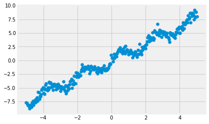

```python
def scatter(x, y):
    """
    Generate a scatter plot using x and y

    Keyword arguments:
    x -- the vector of values x
    y -- the vector of values y
    """
    plt.figure(figsize=(8, 6))

    # YOUR CODE HERE

x = data['x']
y = data['y']
plt.scatter(x,y)
plt.show()
```

**Question 1.2:** Describe any significant observations about the distribution of the data. How can you describe the relationship between $x$ and $y$?

Answer: The relationship between x and y looks roughly linear, but there is some sinosoidal variation in the data as well.

**Question 1.3:** The data looks roughly linear, with some extra noise. For now, let's assume that the data follows some linear model, parametrized by $\theta$:

$$\Large \hat{y} = \theta \cdot x $$

Define a linear model function that estimates a value $\hat{y}$ given $x$ and $\theta$.

```python
def linear_model(x, theta):
    """
    Returns the estimate of y given x and theta

    Keyword arguments:
    x -- the vector of values x
    theta -- the scalar theta
    """
    y_hat = theta*x
    # YOUR CODE HERE
    return y_hat
```

```python
# run this cell
linear_model(0, 1)
```

```
0
```

```python
# run this cell
np.sum(linear_model(np.array([3, 5]), 3))
```

```
24
```

```python
# run this cell
linear_model(np.array([7, 8]), 4).mean()
```

```
30.0
```

**Question 1.4:** In class, we learned that the $L^2$ (or squared) loss function is smooth and continuous. Let's use $L^2$ loss to evaluate our estimate on $\theta$ and predict an optimal value for $\theta$, named $\theta^*$. Define the $L^2$ loss function `l2_loss` below.

```python
def l2_loss(y, y_hat):
    """
    Returns the average l2 loss given y and y_hat

    Keyword arguments:
    y -- the vector of true values y
    y_hat -- the vector of predicted values y_hat
    """
    loss = np.mean((y-y_hat)**2)
    return loss
```

```python
# run this cell
l2_loss(2, 1)
```

```
1.0
```

```python
# run this cell
l2_loss(np.array([1, 1, 1]), np.array([4, 1, 4]))
```

```
6.0
```

**Question 1.5:** First, visualize the: $L^2$ loss as a function of $\theta$, where several different values of $\theta$ are given. Be sure to label your axes properly. You plot should look something like this:

[figure not shown]

What looks like the optimal $\theta^*$ value based on the visualization? Set `theta_star_guess` to the value of $\theta$ that appears to minimize our loss.

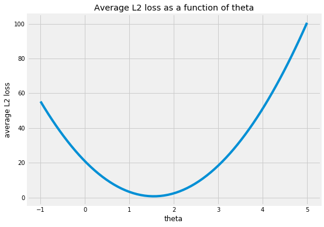

```python
def visualize(x, y, thetas):
    """
    Plots the average l2 loss for given x, y as a function of theta.
    Use the functions you wrote for linear_model and l2_loss.

    Keyword arguments:
    x -- the vector of values x
    y -- the vector of values y
    thetas -- the vector containing different estimates of theta
    """
    avg_losses = []
    for theta in thetas:
        y_hat = linear_model(x, theta)

        avg_loss = l2_loss(y, y_hat) # Calculate the loss here for each value of theta
        avg_losses.append(avg_loss)
    plt.figure(figsize=(8,6))

    plt.plot(thetas, avg_losses) # Create your plot here
    plt.ylabel("average L2 loss")
    plt.xlabel("theta")
    plt.title("Average L2 loss as a function of theta")


thetas = np.linspace(-1, 5, 70)
visualize(x, y, thetas)
plt.show()
theta_star_guess = 1.5
```

```python
print(l2_loss(3, 2) == 1)
print(l2_loss(0, 10) == 100)
print(1 <= theta_star_guess <= 2)
```

```
True
True
True
```

## Section 2: Fitting our Simple Model

Now that we have defined a simple linear model and loss function, let's begin working on fitting our model to the data.

**Question 2.1:** Let's confirm our visual findings for optimal $\theta^*$. First, find the analytical solution for the optimal $\theta^*$ for average $L^2$ loss. Of the three options, below, which is the correct answer? Highlight your answer in <font color = "red">red</font> (double click this cell if you don't know how to do this).

1. $$\Large {\theta}^* = \frac{\sum x_i + y_i}{\sum x_i^2}$$
2. $$\Large {\theta}^* = \frac{\sum x_iy_i}{\sum x_i}$$
3. <font color = "red">$$\Large {\theta}^* = \frac{\sum x_iy_i}{\sum x_i^2}$$
   </font>

**Question 2.2:** Now that we have the analytic solution for $\theta^*$, implement the function `find_theta` that calculates the numerical value of $\theta^*$ based on our data $x$, $y$.

```python
def find_theta(x, y):
    """
    Find optimal theta given x and y

    Keyword arguments:
    x -- the vector of values x
    y -- the vector of values y
    """
    theta_opt = np.sum((x*y))/np.sum(x**2)

    return theta_opt
```

```python
t_star = find_theta(x, y)
print(f'theta_opt = {t_star}')

assert 1.4 <= t_star <= 1.6
```

```
theta_opt = 1.5502648085962225
```

**Question 2.3:** Now, let's plot our loss function again using the `visualize` function. But this time, add a vertical line at the optimal value of theta (plot the line $x = \theta^*$). Your plot should look something like this:

[figure not shown]

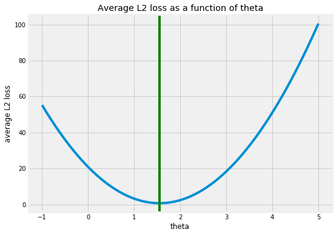

```python
theta_opt = visualize(x, y, thetas)

plt.axvline(x=t_star, color='g')
plt.show()
```

**Question 2.4:** We now have an optimal value for $\theta$ that minimizes our loss. In the cell below, plot the scatter plot of the data from Question 1a (you can reuse the `scatter` function here). But this time, add the line $\hat{y} = \theta^* \cdot x$ using the $\theta^*$ you computed above. Your plot should look something like this:

[figure not shown]

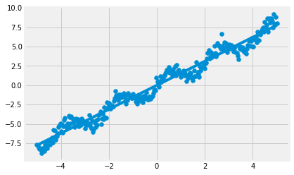

```python
theta_opt = plt.scatter(x,y)
plt.plot(x,(t_star*x))
plt.show()
```

**Question 2.5:** Great! It looks like our estimate for $\theta$ is able to capture a lot of the data with a single parameter. Now let's try to remove the linear portion of our model from the data to see if we missed anything.

The remaining data is known as the residual, $r=y-\theta^* \cdot x$. Below, write a function to find the residual and plot the residuals corresponding to x in a scatter plot. Plot a horizontal line at $y=0$ to assist visualization.

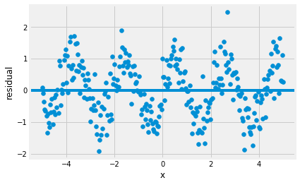

```python
def visualize_residual(x, y):
    """
    Plot a scatter plot of the residuals, the remaining
    values after removing the linear model from our data.

    Keyword arguments:
    x -- the vector of values x
    y -- the vector of values y
    """

    r = y-linear_model(x, t_star) #t_star is the optimal value of theta

    plt.scatter(x,r)
    plt.xlabel("x")
    plt.ylabel("residual")
    plt.axhline(y=0)

visualize_residual(x, y)
```

**Question 2.6:** What does the residual look like? Do you notice a relationship between $x$ and $r$?

Answer: The residuals of this function, or the part that remains after removing the linear part of the model, are sinosoidal. If the relationship between x and y was simply linear, we would expect the residuals to be random. Since they appear to form another function it provides evidence that a linear model is not sufficiently descriptive of the relationship.

## Section 3: Increasing Model Complexity

It looks like the remaining data is sinusoidal, meaning our original data follows a linear function and a sinusoidal function. Let's define a new model to address this discovery and find optimal parameters to best fit the data:

$$\Large \hat{y} = \theta_1x + sin(\theta_2x) $$

Now, our model is parameterized by both $\theta_1$ and $\theta_2$, or composed together, $\vec{\theta}$.

Note that a generalized sine function $a\sin(bx+c)$ has three parameters: amplitude scaling parameter $a$, frequency parameter $b$ and phase shifting parameter $c$. We can assume that the scaling and shifting parameter ($a$ and $c$ in this case) are 1 and 0 respectively.

**Question 3.1:** In the following cell, **explain why we can assume the scaling parameter to be 1 and shifting parameter to be 0 based on the residual plot in Question 2e**.

You might find the following code helpful in visualizing all three parameters.

```
def plot_sin_generalized(a,b,c,label=None):
    """Plot a sin function with three parameters"""
    X = np.linspace(-5, 5)
    Y = a * np.sin(b*X + c)
    plt.scatter(X, Y, label=label)
    plt.legend()
```

You can try plotting:

```
plot_sin_generalized(1,1,1, label='sin(x)')
plot_sin_generalized(1,1,2, label='sin(x + 2)')
plot_sin_generalized(1,2,2, label='sin(2x + 2)')
plot_sin_generalized(2,2,2, label='2sin(2x + 2)')
```

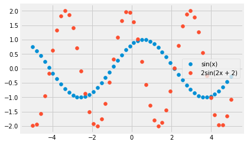

```python
def plot_sin_generalized(a,b,c,label=None):
    """Plot a sin function with three parameters"""
    X = np.linspace(-5, 5)
    Y = a * np.sin(b*X + c)
    plt.scatter(X, Y, label=label)
    plt.legend()

plot_sin_generalized(1,1,1, label='sin(x)')
#plot_sin_generalized(1,1,2, label='sin(x + 2)')
#plot_sin_generalized(1,2,2, label='sin(2x + 2)')
plot_sin_generalized(2,2,2, label='2sin(2x + 2)')
```

Possible Answer: The shifting parameter is 0 because the graph has a point at the origin, meaning it is not shifted left or right. The scaling parameter is 1 because the points seem to be spread around a sine wave going from -1 to 1.

**Question 3.2:** As in Question 1, write a function that predicts a value $\hat{y}$ given an input $x$ based on our new model.

*Hint:* Try to do this without using for loops. The `np.sin` function may help you.

```python
def sin_model(x, theta_1, theta_2):
    """
    Predict the estimate of y given x, theta_1, theta_2

    Keyword arguments:
    x -- the vector of values x
    theta_1 -- the scalar value theta_1
    theta_2 -- the scalar value theta_2
    """
    y_hat = theta_1*x+np.sin(theta_2*x)
    return y_hat
```

```python
sin_model(4, 1.5, 2)
```

```
6.9893582466233815
```

```python
print(np.isclose(sin_model(1, 1, np.pi), 1.0000000000000002))
# Check that we accept x as arrays
assert len(sin_model(x, 2, 2)) > 1
```

```
True
```

**Question 3.3:** In this question your job is to match the left and right sides of the equations for:

1. The $L^2$ loss for for the `sin` model, $\hat{y} = \theta_1x + sin(\theta_2x)$. We'll call that $L(x, y, \theta_1, \theta_2)$.
2. The partial derivatives of the `sin` model loss functions, $\frac{\partial L }{\partial \theta_1}, \frac{\partial L }{\partial \theta_2}$.

Notice that we now have $\vec{x}$ and $\vec{y}$ instead of $x$ and $y$. This means that when determining the loss function $L(x, y, \theta_1, \theta_2)$, you'll need to take the average of the squared losses for each $y_i$, $\hat{y_i}$ pair.

As your answer below, match the right side (letters) to the correct left sides (numbers).

1. $L(x, y, \theta_1, \theta_2)$
2. $\frac{\partial L}{\partial \theta_1}$
3. $\frac{\partial L}{\partial \theta_2}$

A. $\frac{1}{n} \sum_{i=1}^n (y_i - \theta_1 x_i - \sin(\theta_2 x_i)) ^ 2$  
B. $-\frac{2}{n} \sum_{i=1}^n (x_i y_i \cos(\theta_2 x_i) - \theta_1 x_i ^ 2 \cos(\theta_2 x_i) - x_i \sin(\theta_2 x_i)\cos(\theta_2 x_i))$  
C. $-\frac{2}{n} \sum_{i=1}^n (x_i y_i - \theta_1 x_i ^ 2 - x_i \sin(\theta_2 x_i))$

Answer:

1. A
2. C
3. B

**Question 3.4:** Now, implement the functions `dt1` and `dt2`, which should compute $\frac{\partial L }{\partial \theta_1}$ and $\frac{\partial L }{\partial \theta_2}$ respectively. Use the formulas you wrote for $\frac{\partial L }{\partial \theta_1}$ and $\frac{\partial L }{\partial \theta_2}$ in the previous exercise. In the functions below, the parameter `theta` is a vector that looks like $( \theta_1, \theta_2 )$.

```python
def dt1(x, y, theta):
    """
    Compute the numerical value of the partial of l2 loss with respect to theta_1

    Keyword arguments:
    x -- the vector of all x values
    y -- the vector of all y values
    theta -- the vector of values theta
    """
    dt1 = (-2*np.mean(x*y-theta[0]*(x**2)-x*np.sin(theta[1]*x)))
    return dt1
```

```python
def dt2(x, y, theta):
    """
    Compute the numerical value of the partial of l2 loss with respect to theta_2

    Keyword arguments:
    x -- the vector of all x values
    y -- the vector of all y values
    theta -- the vector of values theta
    """
    dt2 = (-2*np.mean(x*y*np.cos(theta[1]*x)-theta[0]*(x**2)*np.cos(theta[1]*x)-
                    x*np.sin(theta[1]*x)*np.cos(theta[1]*x)))
    return dt2
```

```python
# This function calls dt1 and dt2 and returns the gradient dt. It is already implemented for you.
def dt(x, y, theta):
    """
    Returns the gradient of l2 loss with respect to vector theta

    Keyword arguments:
    x -- the vector of values x
    y -- the vector of values y
    theta -- the vector of values theta
    """
    return np.vstack([
        dt1(x, y, theta),
        dt2(x, y, theta)
    ])
```

```python
print(np.isclose(dt1(x, y, [0, np.pi]), -25.376660670924529))
print(np.isclose(dt2(x, y, [0, np.pi]), 1.9427210155296564))
```

```
True
True
```

## Section 4: Gradient Descent

Now try to solve for the optimal $\theta^*$ analytically...

**Just kidding!**

You can try but we don't recommend it. When finding an analytic solution becomes difficult or impossible, we resort to alternative optimization methods for finding an approximate solution.

So let's try implementing a numerical optimization method: gradient descent!

**Question 4.1:** Implement the `grad_desc` function that performs gradient descent for a finite number of iterations. This function takes in array $x$, array $y$, and an initial value for $\theta$ (`theta`). `alpha` will be the learning rate (or step size, whichever term you prefer). In this part, we'll use a static learning rate that is the same at every time step.

At each time step, use the gradient and `alpha` to update your current `theta`. Also at each time step, be sure to save the current `theta` in `theta_history`, along with the $L^2$ loss (computed with the current `theta`) in `loss_history`.

Hints:

- Write out the gradient update equation (1 step). What variables will you need for each gradient update? Of these variables, which ones do you already have, and which ones will you need to recompute at each time step?
- You may need a loop here to update `theta` several times.

```python
# Run me
def init_t():
    """Creates an initial theta [0, 0] as a starting point for gradient descent"""
    return np.zeros((2,1))
```

```python
def grad_desc(x, y, theta, num_iter=20, alpha=0.1):
    """
    Run gradient descent update for a finite number of iterations and static learning rate

    Keyword arguments:
    x -- the vector of values x
    y -- the vector of values y
    theta -- the vector of values theta to use at first iteration
    num_iter -- the max number of iterations
    alpha -- the learning rate (also called the step size)

    Return:
    theta -- the optimal value of theta after num_iter of gradient descent
    theta_history -- the series of theta values over each iteration of gradient descent
    loss_history -- the series of loss values over each iteration of gradient descent
    """
    theta_history = []
    loss_history = []
    #theta = np.array(theta).reshape((2,))
    for run in np.arange(0,num_iter):
        theta_history.append(theta)
        y_hat = theta[0]*x+np.sin(theta[1]*x)
        L2_loss = l2_loss(y, y_hat)
        loss_history.append(L2_loss)
        #when theta is a vector, the gradient is also a vector

        grad = dt(x,y, theta) #this is a 2x1 vector
        theta = theta-alpha*grad #theta is also a vector, this performs element wise



    return theta, theta_history, loss_history
```

```python
grad_desc(x, y, np.array([0, np.pi]).reshape((2,1)), num_iter=20, alpha=0.1)
```

[output not shown]

```
(array([[1.5164],
        [2.9945]]), [array([[0.    ],
         [3.1416]]), array([[2.5377],
         [2.9473]]), array([[0.8363],
         [2.7349]]), array([[2.0589],
         [3.1534]]), array([[1.1429],
         [3.0779]]), array([[1.7626],
         [3.0342]]), array([[1.346 ],
         [2.9776]]), array([[1.6373],
         [3.0242]]), array([[1.4322],
         [2.9874]]), array([[1.5771],
         [3.0086]]), array([[1.4752],
         [2.9895]]), array([[1.5475],
         [3.001 ]]), array([[1.4965],
         [2.9916]]), array([[1.5327],
         [2.9977]]), array([[1.5071],
         [2.993 ]]), array([[1.5252],
         [2.9961]]), array([[1.5124],
         [2.9938]]), array([[1.5215],
         [2.9954]]), array([[1.5151],
         [2.9943]]), array([[1.5196],
         [2.9951]])], [19.49000412080223,
  8.854538470652102,
  4.891304423235766,
  2.8132077364958588,
  1.3900272465853114,
  0.7433982280740422,
  0.47470169607352225,
  0.3493027920305687,
  0.28357772858046226,
  0.2523870059912253,
  0.23647089168112975,
  0.22870562256359567,
  0.22476090765358953,
  0.22280638440622336,
  0.22181791158726527,
  0.22132458745282468,
  0.22107586369439416,
  0.2209513173559894,
  0.22088863597149408,
  0.22085719947793678])
```

```python
t = init_t()
t_est, ts, loss = grad_desc(x, y, t, num_iter=20, alpha=0.1)

print(len(ts) == len(loss) == 20) # theta history and loss history are 20 items in them
print(ts[0].shape == (2,1)) # theta history contains theta values
print(np.isscalar(loss[0])) # loss history is a list of scalar values, not vector

print(loss[1] - loss[-1] > 0) # loss is decreasing

print(np.allclose(np.sum(t_est), 4.5, atol=2e-1))  # theta_est should be close to our value
```

```
True
True
True
True
True
```

**Question 4.2:** Let's visually inspect our results of running gradient descent to optimize $\theta$. Plot our x values with our model's predicted y values over the original scatter plot. Did gradient descent successfully optimize $\theta$?

```python
# Run me
t = init_t()
t_est, ts, loss = grad_desc(x, y, t)
```

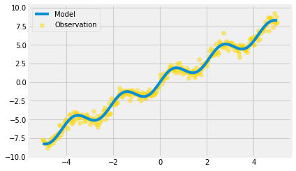

```python
y_pred = sin_model(x, t_est[0], t_est[1])

plt.plot(x, y_pred, label='Model')
plt.scatter(x, y, alpha=0.5, label='Observation', color='gold')
plt.legend()
plt.show()
```

**Question 4.3:** Let's visualize gradient descent to see how it converges. Plot the loss values over each iteration of gradient descent.

```
Text(0.5,1,'Learning Rate')
```

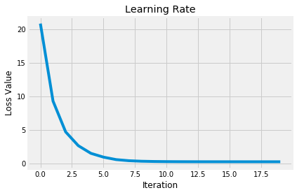

```python
plt.plot(loss) # Plot of loss history for static learning rate
plt.xlabel('Iteration')
plt.ylabel('Loss Value')
plt.title("Learning Rate")
# YOUR CODE HERE
```

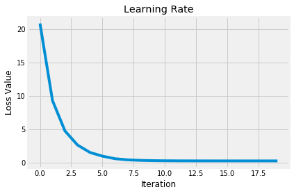

```python
plt.plot(loss)
plt.xlabel('Iteration')
plt.ylabel('Loss Value')
plt.title("Learning Rate")
plt.show()
```

**Question 4.4:** Describe the approach of modifying the alpha parameter on each iteration and how a plot of loss versus iteration number would differ from the one you just made. Give some intuition for your answer.

```
Answer: A dynamic learning rate describes a process by which the alpha parameter is modified on each iteration. This is a more effective way of finding the optimal theta because the learning rate is larger when the guesses are farther away from the optimum, but it decreases as it approaches the optimum so as to not overshoot. The graph of the loss would converge more quickly with a dynamic learning rate.
```